# Praca domowa 2

Bartosz Kitewski

## Dane

Dane wykorzystane w Pracy domowej 2 dotyczą wyników egzaminów z 3 umiejętności: czytania, pisania i operacji matematycznych. Dodatkowo dostępne są podstawowe informacje o studentach i ich rodzicach. Opis wszystkich kolumn znajduje się również w pliku `README.md`.

| Zmienna | Opis |
| --- | --- |
| **gender** | płeć |
| **race.ethnicity** | pochodzenie etniczne |
| **parental.level.of.education** | wykształcenie rodziców |
| **lunch** | jaki obiad jedli uczniowie w dniu egzaminu |
| **test.preparation.course** | czy uczeń odbył kurs przygotowujący |
| **math.score** | wynik egzaminu z matematyki |
| **reading.score** | wynik egzaminu z czytania |
| **writing.score** | wynik egzaminu z pisania |

## Zadanie 1

Jak wyglądają rozkłady wyników uczniów z trzech przedmiotów (matematyka, czytanie, pisanie)?

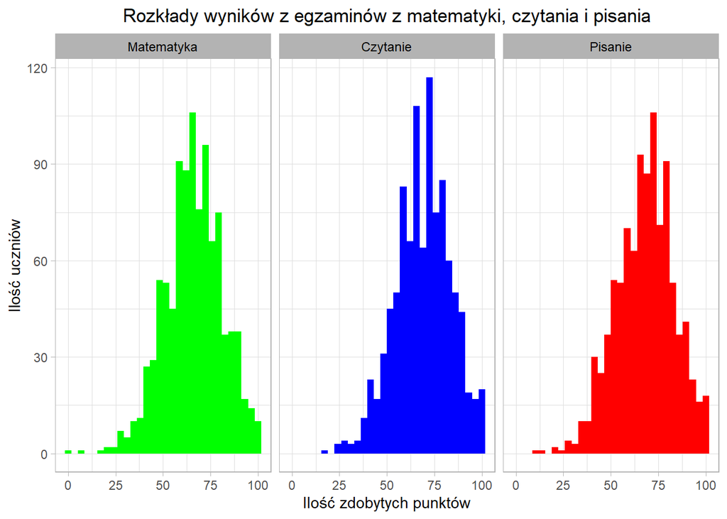

```r
subject.labs <- c("Matematyka", "Czytanie", "Pisanie")
names(subject.labs) <- c("math.score", "reading.score", "writing.score")

df2 <- df %>% tidyr::pivot_longer(
  cols = c("math.score", "reading.score", "writing.score"),
  names_to = "subject",
  values_to = "score"
)
df2 %>% ggplot(aes(x=score, fill = subject)) +
  geom_histogram() +
  scale_fill_manual(values = c("math.score" = "green", "writing.score" = "red", "reading.score" = "blue")) +
  facet_wrap(~ subject, ncol=3, labeller = labeller(subject=subject.labs))+
  labs(
    title = "Rozkłady wyników z egzaminów z matematyki, czytania i pisania",
    x = "Ilość zdobytych punktów",
    y = "Ilość uczniów"
  ) + theme_light()  +
  theme(
    legend.position = "none",
    plot.title = element_text(hjust=0.5),
    strip.text.x = element_text(color = "black", size = 9)
  )
```

**Komentarz:** Każdy z rozkładów jest podobny. Wykres gęstości matematyki jest lekko przesunięty na lewo, czyli wyniki z matematyki były gorsze od wyników z pisania i czytania. Najwięcej uczniow miało wynik pomiędzy 67.5 a 75 pubktów. Tylko nieliczni mieli mniej niż 25 punktów.

## Zadanie 2

Czy istnieje zauważalna różnica w wynikach między uczniami i uczennicami?

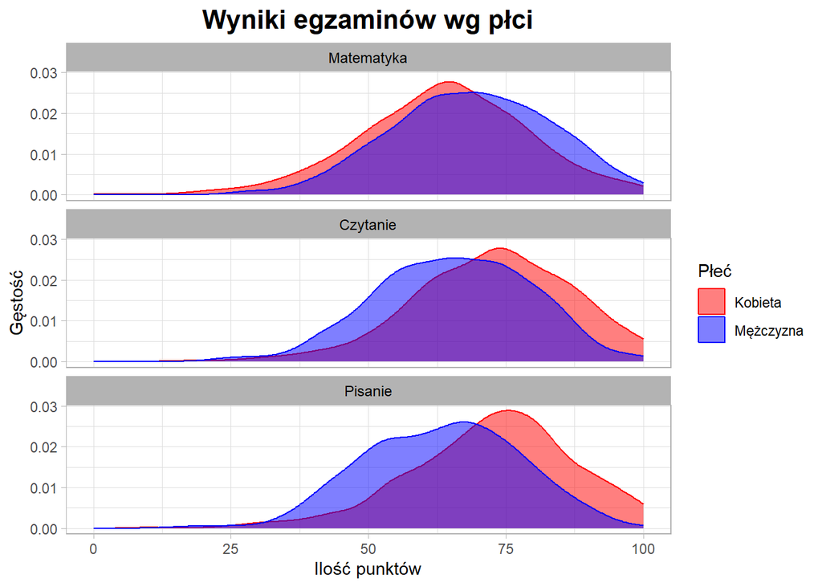

```r
df2 %>% ggplot(aes(x=score, fill=gender, colour = gender)) +
  scale_fill_discrete(palette = c("red", "blue"),name = "Płeć", labels = c("Kobieta", "Mężczyzna"))+
  scale_color_discrete(palette = c("red", "blue"),name = "Płeć", labels = c("Kobieta", "Mężczyzna")) +
  geom_density(alpha = 0.5, adjust=1) +
  facet_wrap(~subject,ncol=1, labeller = labeller(subject = subject.labs)) +
  labs(
    title = "Wyniki egzaminów wg płci",
    x = "Ilość punktów",
    y = "Gęstość"
  ) +
  theme_light()+
  theme(
    plot.title = element_text(hjust=0.5, size = 16, face = "bold"),
    strip.text.x = element_text(color = "black", size = 9)
  )
```

**Komentarz:** Z wykresu widać, że matematyka poszła lepiej uczniom niż uczennicom, Chociaż maksymalny wynik z matematyki miało porównywalnie wiele uczniów i uczennic. Natomiast egzamin z czytania i pisania poszedł zdecydowanie lepiej uczennicom.

## Zadanie 3

Czy uczniowie, którzy ukończyli kurs przygotowawczy, osiągają lepsze wyniki niż pozostali?

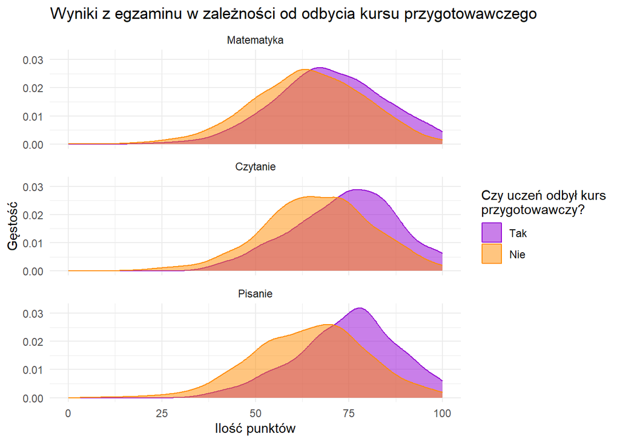

```r
df2 %>% ggplot(aes(x=score, fill = test.preparation.course, colour = test.preparation.course)) +
  geom_density(alpha=0.5) +
  scale_fill_discrete(palette = c("darkviolet", "darkorange"),name = stringr::str_wrap("Czy uczeń odbył kurs przygotowawczy?",                               width = 20), labels = c("Tak", "Nie"))+
  scale_color_discrete(palette = c("darkviolet", "darkorange"),name = stringr::str_wrap("Czy uczeń odbył kurs przygotowawczy?",                               width = 20),labels = c("Tak", "Nie")) +
  facet_wrap(~subject, ncol = 1, labeller = labeller(subject = subject.labs)) +
  labs(
    title = "Wyniki z egzaminu w zależności od odbycia kursu przygotowawczego",
    x = "Ilość punktów",
    y = "Gęstość"
  ) +
  theme(
    plot.title = element_text(hjust = 0.5),
    legend.key.justification = "centre"
  ) + theme_minimal()
```

**Komentarz:** Z wykresów można zauważyć, że uczniowie, którzy ukończyli kurs przygotowawczy, mają lepsze wynik od uczniów, którzy go nie ukończyli. Najmniejsza różnica między wynikami osób ‘z kursem’ i ‘bez kursu’ jest z egzaminu z matematyki.

## Zadanie 4

Jaki jest związek między poziomem wykształcenia rodziców a średnimi wynikami uczniów?

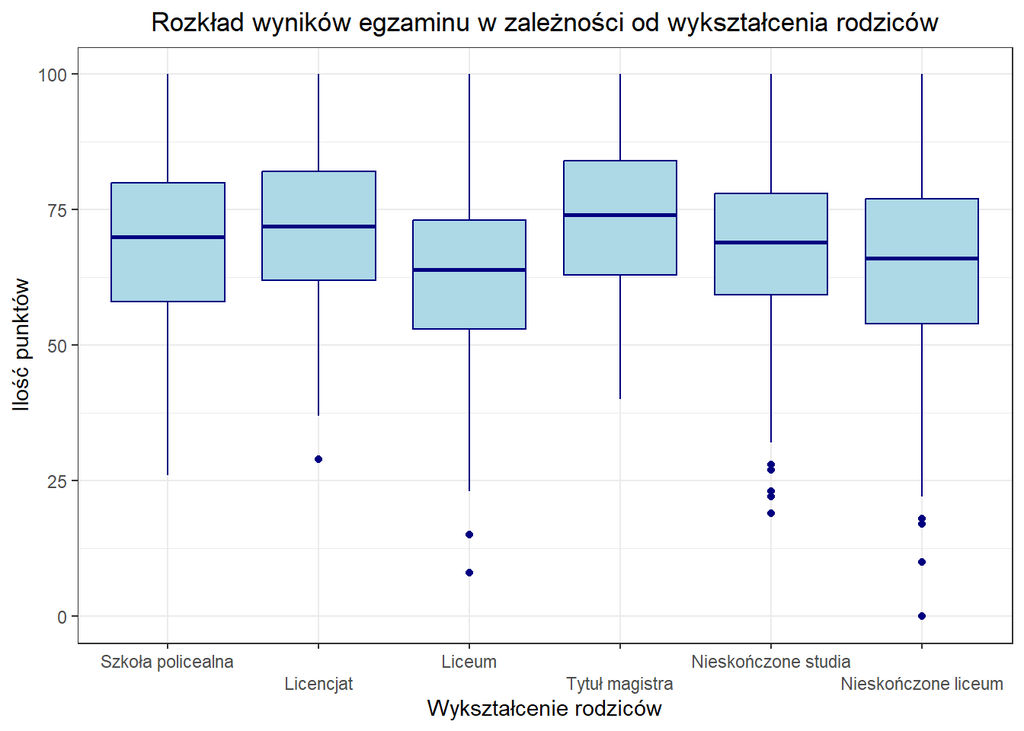

```r
lvl.edu.labs <- c("Nieskończone liceum", "Liceum", "Nieskończone studia", "Szkoła policealna", "Licencjat", "Tytuł magistra")
names(lvl.edu.labs) <- c("some high school", "high school", "some college", "associate's degree", "bachelor's degree", "master's degree")

df2 %>% ggplot(aes(x=factor(parental.level.of.education), y=score)) +
  geom_boxplot(color = "navyblue", fill="lightblue") +
  scale_x_discrete(labels = lvl.edu.labs, guide = guide_axis(n.dodge=2)) +
  labs(
    title = "Rozkład wyników egzaminu w zależności od wykształcenia rodziców",
    x = "Wykształcenie rodziców",
    y = "Ilość punktów"
  ) + theme_bw()+ theme(
    plot.title = element_text(hjust = 0.5)
  )
```

**Komentarz:** Z wykresu można zauważyć,że dzieci z rodzicami z tytułem magistra osiągają średnio najlepsze wyniki z medianą ok. 74 punkty. Następnie najlepsze wyniki mają kolejno uczniowie z rodzicami z licencjatem, po skończeniu szkoły policealnej(Associate’s degree), z nieskończonymi studiami oraz nieskończonym liceum. Najgorsze wyniki mają dzieci osób, które skończyły liceum.

## Zadanie 5

Czy płeć i wykształcenie rodzica wpływa na wynik z matematyki?

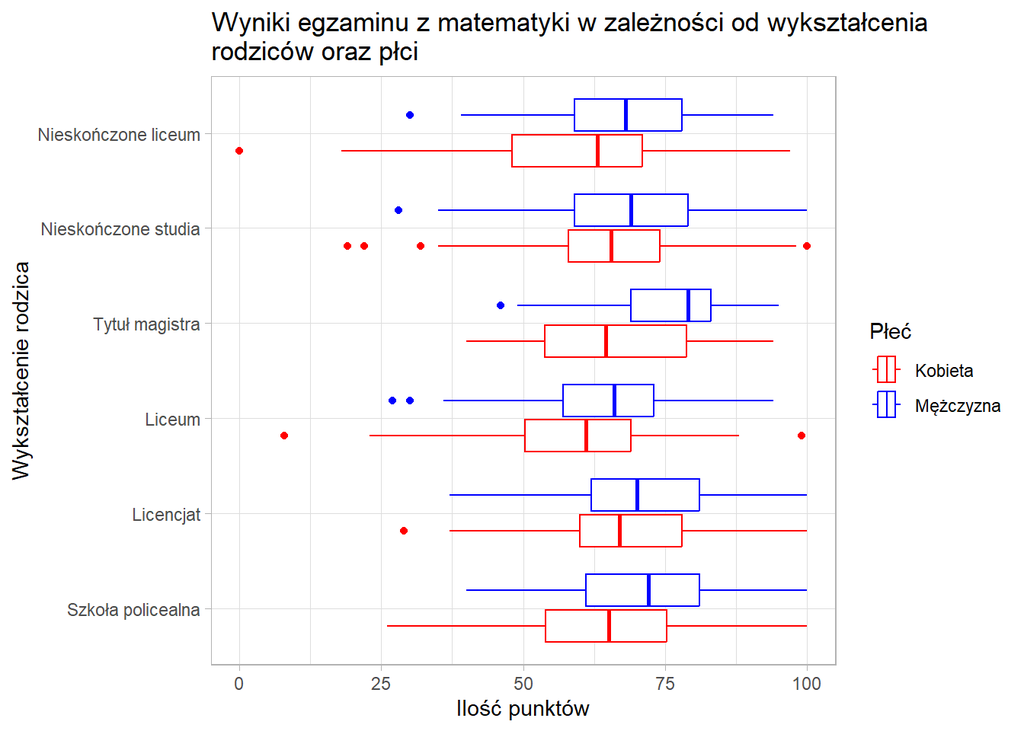

```r
df2 %>% filter(subject == "math.score") %>%
  ggplot(aes(x=score, y =factor(parental.level.of.education), color=gender)) +
  geom_boxplot() +
  scale_color_discrete(palette = c("red", "blue"),name = "Płeć", labels = c("Kobieta", "Mężczyzna")) +
  scale_y_discrete(labels = lvl.edu.labs) +
  labs(
    title = stringr::str_wrap("Wyniki egzaminu z matematyki w zależności od wykształcenia rodziców oraz płci", width = 60),
    x = "Ilość punktów",
    y = "Wykształcenie rodzica"
  ) + theme(
    plot.title = element_text(hjust=0.5, )
  ) + theme_light()
```

**Komentarz:** Z wykresu widać, że najlepsze wyniki mają mężczyźni z rodzicami, którzy mają tytuł magistra. Można zauważyć, że u mężczyzn istnieje zależność między wynikami z mateamtyki a wykształceniem rodziców. Najlepsze wyniki mają mężczyźni z rodzicami z tytułem magistra oraz po szkole policealnej, natomiast najgorsze - z rodzicami po liceum lub rodzicami, którzy nieskończyli liceum. U dziewczyn, w przeciwieństwie do chłopaków, są mniejsze różnice porównując wykształcenie rodziców. Chociaż nadal można dostrzec pewne różnice, np. średnio najlepsze wyniki mają uczennice z rodzicami z licencjatem. Następnie porównując po płci można stwierdzić, że chłopacy osiągają zdecydowanie lepsze wyniki z matematyki niż dziewczyny. Szczególnie duża różnica jest z rodzicami magistrami.

## Zadanie 6

Czy istnieje zależność między wynikami z matematyki a wynikami z czytania lub pisania?

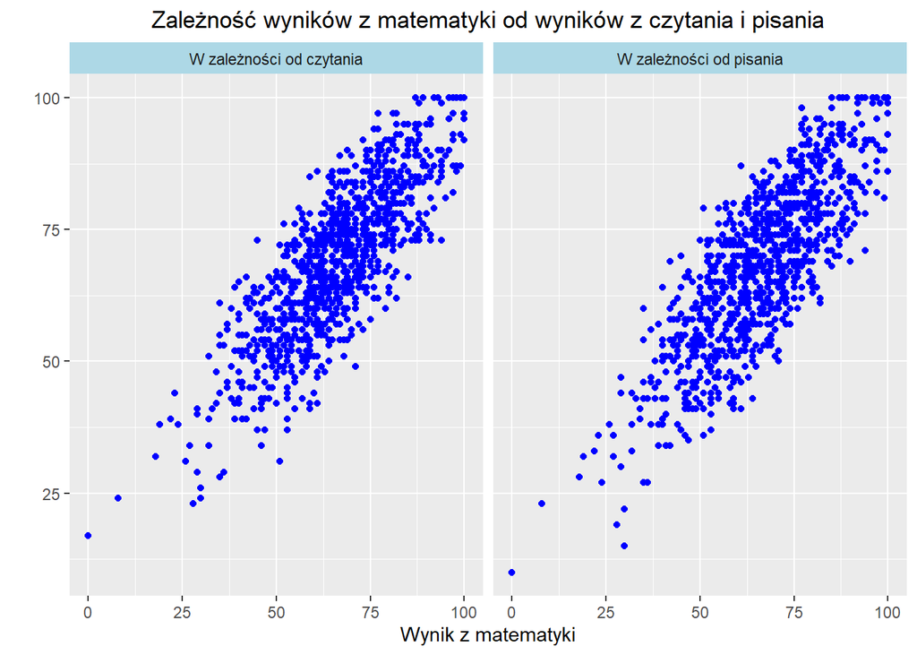

```r
rw.labs <- c("W zależności od czytania", "W zależności od pisania")
names(rw.labs) <- c("reading.score", "writing.score")

df %>% tidyr::pivot_longer(
  cols = c("reading.score", "writing.score"),
  names_to = "rw",
  values_to = "rw.score"
) %>% ggplot(aes(x=math.score, y=rw.score)) +
  geom_point(color = "blue") +
  facet_wrap(~rw, labeller = labeller(rw = rw.labs)) +
  labs(
    title = "Zależność wyników z matematyki od wyników z czytania i pisania",
    x = "Wynik z matematyki",
    y = ""
  ) + theme(
    strip.background = element_rect(fill='lightblue'),
    plot.title = element_text(hjust=0.5)
  )
```

**Komentarz:** W obu przypadkach można dostrzec pewną zależność, która jest bliska zależności liniowej. Z wykresu dostrzegam, że czytanie jest bardziej skolerowwane z matematyką niż pisanie z matematyką, ponieważ wykres zależności czytania od matematyki jest bardziej skondensowany. Jednak nie można tego powiedzieć z pewnością.